# Lab 4

Daniella Madubuike

October 9, 2017

### Question 1a

The number of points scored by each team in a tournament is normally distributed, with mean μ = 32 and standard deviation σ = 7. What is the probability of: A team scoring 20 points or fewer? Plot the density function and shade the area.

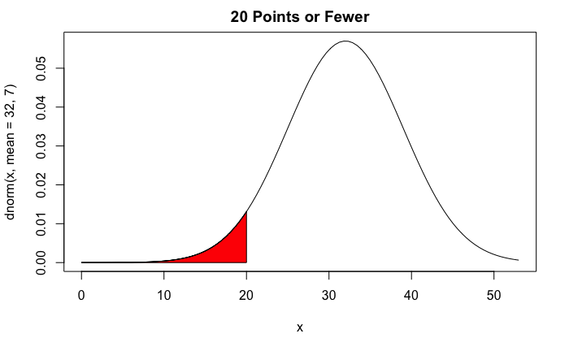

```r
curve(dnorm(x, mean = 32, 7), from = 0, to = 53, main = '20 Points or Fewer')
cord.x <- c(0, seq(0,20,0.01), 20)
cord.y <- c(0, dnorm(seq(0,20,0.01), mean = 32, sd = 7), 0)
polygon(cord.x, cord.y, col = "red")
```

### Question 1b

A team scoring more than 35 points? Plot the density function and shade the area.

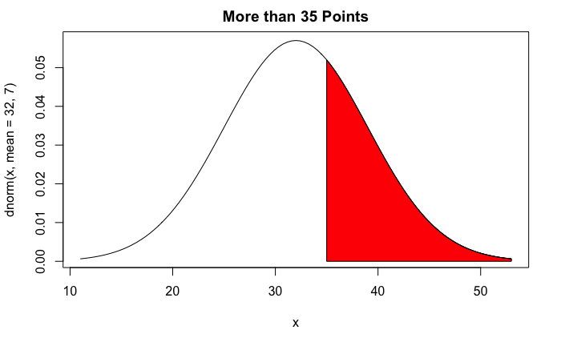

```r
curve(dnorm(x, mean = 32, 7), from = 11, to = 53, main = 'More than 35 Points')
cord.x <- c(35, seq(35,53, 0.01), 53)
cord.y <- c(0, dnorm(seq(35,53,0.01), mean = 32, sd = 7), 0)
polygon(cord.x, cord.y, col = "red")
```

### Question 1c

A team scoring between 20 and 40 points? Plot the density function and shade the area.

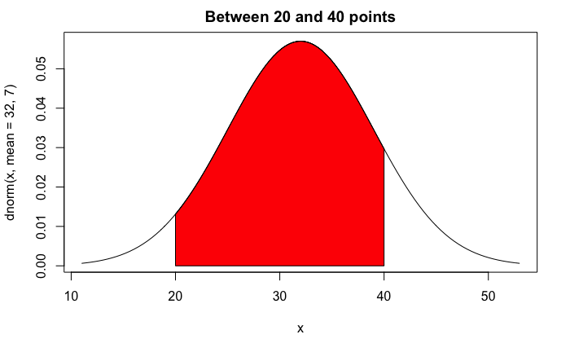

```r
curve(dnorm(x, mean = 32, 7), from = 11, to = 53, main = 'Between 20 and 40 points')
cord.x <- c(20, seq(20,40, 0.01), 40)
cord.y <- c(0, dnorm(seq(20,40,0.01), mean = 32, sd = 7), 0)
polygon(cord.x, cord.y, col = "red")
```

### Question 2a

The number of comments per post on a social media site is exponentially distributed, with the average post receiving ten comments. What percentage of posts get: Fewer than three comments? Plot the density function and shade the area.

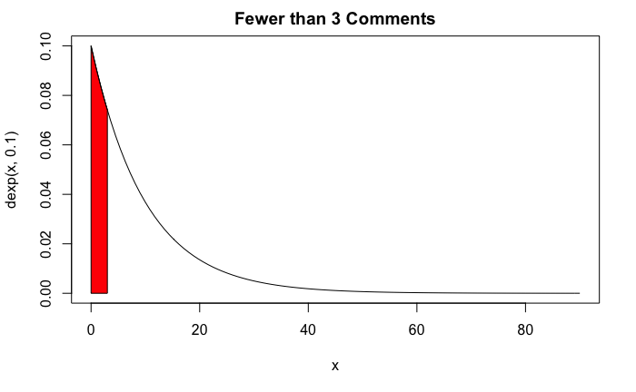

```r
x <- dexp(3, rate = 0.1)
curve(dexp(x, 0.1), from = 0, to = 90, main = 'Fewer than 3 Comments')
cord.x <- c(0, seq(0,3,0.01), 3)
cord.y <- c(0, dexp(seq(0,3,0.01), 0.1), 0)
polygon(cord.x, cord.y, col = "red")
```

### Question 2b

More than 20 comments? Plot the density function and shade the area

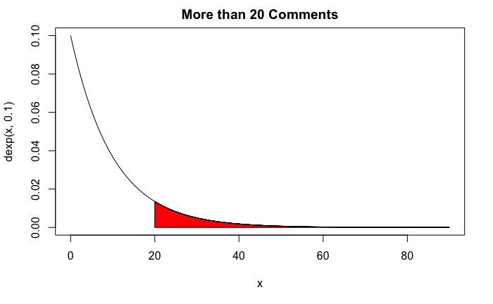

```r
x <- pexp(20, rate = 0.1, lower.tail = FALSE)
curve(dexp(x, 0.1), from = 0, to = 90, main = 'More than 20 Comments')
cord.x <- c(20, seq(20,90,0.01), 90)
cord.y <- c(0, dexp(seq(20,90,0.01), 0.1), 0)
polygon(cord.x, cord.y, col = "red")
```

### Question 2c

Between five and ten comments? Plot the density function and shade the area.

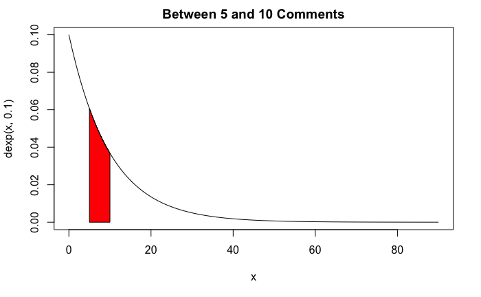

```r
curve(dexp(x,0.1), from = 0, to = 90, main = 'Between 5 and 10 Comments')
cord.x <- c(5, seq(5,10, 0.01), 10)
cord.y <- c(0, dexp(seq(5,10,0.01), 0.1), 0)
polygon(cord.x, cord.y, col = "red")
```

### Question 3a

Basic raster creation and calculation: Create a first raster (30 rows × 30 columns) and assign values to the raster based on random values from a uniform distribution. Plot the raster and the histogram.

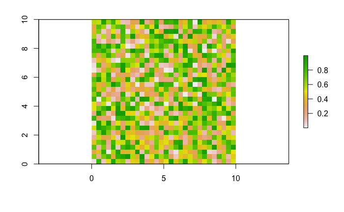

```r
if(!require(raster)) install.packages("raster")
library(raster)
ras <- raster(nrows=30,ncols=30,xmn=0,xmx=10,ymn=0,ymx=10)
set.seed = 100
ras[] <- runif(ncell(ras))
plot(ras)
```

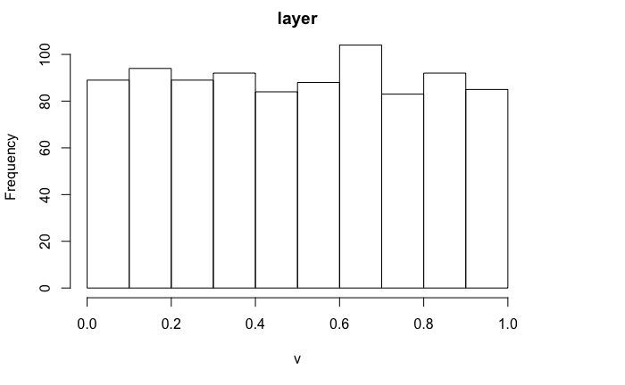

```r
hist(ras)
```

### Question 3b

Create a second raster (30 rows × 30 columns) and assign values to the raster based on random values from a normal distribution. Plot the raster and the histogram.

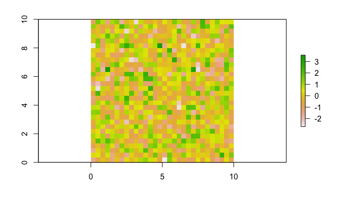

```r
ras2 <- raster(nrows=30,ncols=30,xmn=0,xmx=10,ymn=0,ymx=10)
set.seed = 200
ras2[] <- rnorm(ncell(ras2))
plot(ras2)
```

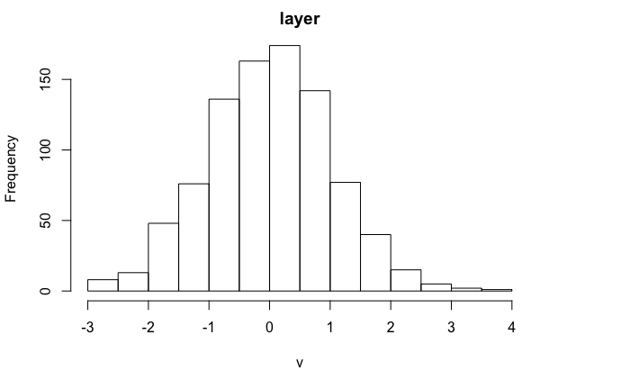

```r
hist(ras2)
```

### Question 3c

Create a third raster (30 rows × 30 columns) and assign values to the raster based on cell-by-cell addition of the first raster and the second raster. Plot the raster and the histogram.

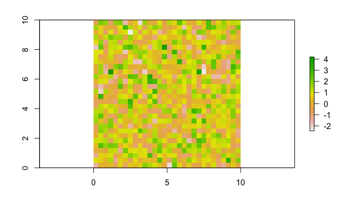

```r
newraster <- ras + ras2
plot(newraster)
```

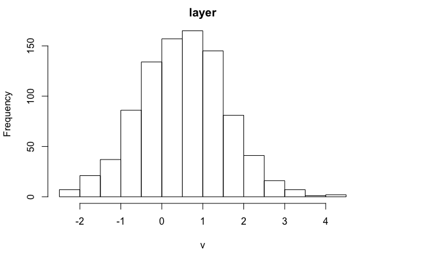

```r
hist(newraster)
```

### Question 3d

Calculate the mean value of the third raster. Reclassify the third raster into a binary image: 1 (cell value > mean value) and 0 (cell value <= mean value). Save the reclassified image to your working directory as a TIFF image.

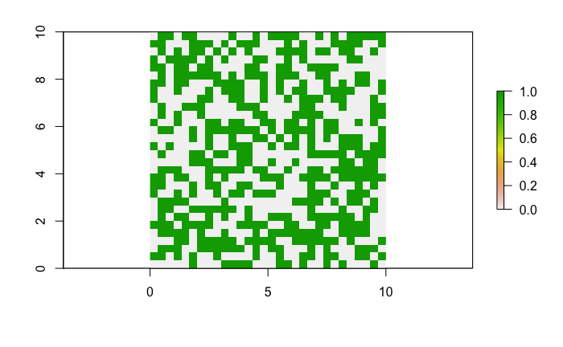

```r
a <- cellStats(newraster,"mean")
newraster[newraster > a ] <- 1
newraster[newraster <= a] <- 0
plot(newraster)
```

```r
writeRaster(newraster,filename = "newraster.tif", overwrite = TRUE)
read <- raster("newraster.tif")
```